# Home Advantage in Soccer: Myth or Reality? An Exploratory Analysis of the English Premier League (1993–2022)

DATS 6101 — Project 1

October 17, 2025

# 1 Abstract

# 2 1. Introduction

Sports performance is never purely an outcome of skill alone. Contextual and environmental factors—ranging from travel fatigue and crowd noise to referee psychology—shape competitive outcomes in subtle yet meaningful ways. Among these contextual factors, **home-field advantage** has long been recognized as one of the most consistent patterns across team sports. The term refers to the observation that teams tend to perform better when playing in their home venue than when playing away.

In soccer, home advantage is often visible to even casual observers: home teams seem more aggressive, confident, and tactically fluid. Yet, quantifying this advantage rigorously requires large-scale data and statistical analysis. The **English Premier League (EPL)** offers an ideal case study: it is among the most competitive and globally watched leagues, with consistent data recording across seasons since its inception in 1992. Despite the influx of international talent and increased parity among clubs, questions remain—does playing at home still matter as much as it once did?

Our **SMART research question** asks:  
> *Does playing at home significantly increase a Premier League team’s likelihood of winning, scoring more goals, and earning more points per game between 1993 and 2022?*

We hypothesize that home teams perform significantly better on average across these metrics, but that the effect may have weakened in recent years due to tactical evolution, professionalization, and pandemic-related conditions. This project combines exploratory data visualization with inferential tests to evaluate the strength and evolution of this effect.

# 3 2. Literature Review

The notion of home-field advantage dates back over a century. Courneya and Carron (1992) provided one of the first meta-analyses, identifying crowd support, familiarity with venue, travel fatigue, and referee bias as key mechanisms. Subsequent research, such as Pollard (2008), confirmed its existence across various sports and leagues, estimating an average home advantage of roughly 60% win rates in soccer. More recent studies have explored its psychological underpinnings: Nevill and Holder (1999) found that noise and crowd size influence referee decisions, while Bryson et al. (2021) observed a sharp decline in home advantage during COVID-19, when games were played without fans.

Despite these insights, most prior work focuses on a single mechanism rather than a holistic quantitative overview. This paper seeks to bridge that gap by combining empirical outcomes (win rates, goals, points) with statistical tests and temporal trends. The EPL serves as a natural testbed given its long history, consistent format, and competitive balance.

# 4 3. Data Description

The dataset used comprises all English Premier League match results between **1993 and 2022**, totaling approximately 11,113 records. Each record includes the home and away teams, the number of goals scored by each (`FTHG` and `FTAG`), the final result (`FTR` coded as “H”, “D”, or “A”), and the season. Data were sourced from public football statistics repositories and curated for consistency.

The dataset has several advantages: large sample size, standardized format, and coverage across nearly three decades. However, it excludes variables such as attendance, travel distance, or player availability—factors that could explain variation in home advantage magnitude. Therefore, this study focuses on observable match-level outcomes rather than deeper causal modeling.

# 5 4. Data Cleaning and Preparation

Before analysis, we must ensure that the dataset is free of major inconsistencies, outliers, and missing values. The EPL data is relatively clean, but small data quality issues—missing score entries or typographical inconsistencies—can bias statistical inference.

```r
df <- read_csv("results.csv", locale = locale(encoding = "latin1"))

# 1) Remove rows with NAs in critical columns
df <- df %>% drop_na(FTHG, FTAG, FTR)

# 2) Remove outliers using IQR rule
df <- df %>% filter(
  between(FTHG, quantile(FTHG, 0.25) - 1.5*IQR(FTHG), quantile(FTHG, 0.75) + 1.5*IQR(FTHG)),
  between(FTAG, quantile(FTAG, 0.25) - 1.5*IQR(FTAG), quantile(FTAG, 0.75) + 1.5*IQR(FTAG))
)
```

This minimal cleaning approach keeps the dataset representative while ensuring robustness against extreme anomalies such as unusually lopsided results.

# 6 5. Methodology

Our analytical strategy combines **descriptive** and **inferential** techniques:

- **Descriptive analysis (EDA):** We calculate proportions of home, away, and draw results; average goals; and average points per game (PPG). Visualizations include bar charts, boxplots, and line graphs over time.
- **Inferential analysis:** We employ chi-square tests to determine whether outcome proportions differ significantly from random chance and t-tests to compare home vs away averages for goals and points.
- **Temporal analysis:** We examine trends over time, focusing on whether home advantage has declined—particularly during 2019–2021 seasons when games occurred without spectators.

By integrating both exploratory visuals and hypothesis testing, we ensure both interpretability and rigor.

# 7 6. Results

## 7.1 6.1 Match Outcomes: Home vs Away

```r
outcomes <- df %>% mutate(Result = case_when(
  FTR == "H" ~ "HomeWin",
  FTR == "A" ~ "AwayWin",
  FTR == "D" ~ "Draw"
)) %>% count(Result) %>% mutate(pct = n / sum(n) * 100)
outcomes
```

```
## # A tibble: 3 × 3
##   Result      n   pct
##   <chr>   <int> <dbl>
## 1 AwayWin  3125  30.5
## 2 Draw     2849  27.8
## 3 HomeWin  4256  41.6
```

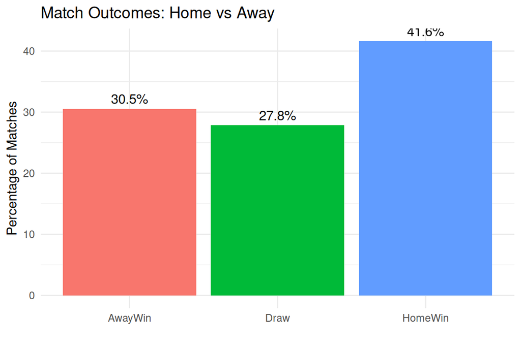

```r
ggplot(outcomes, aes(x = Result, y = pct, fill = Result)) +
  geom_col(show.legend = FALSE) +
  geom_text(aes(label = paste0(round(pct,1), "%")), vjust = -0.5) +
  labs(title = "Match Outcomes: Home vs Away", x = "", y = "Percentage of Matches") +
  theme_minimal()
```

### 7.1.1 Interpretation

```r
obs <- outcomes$n
chisq.test(x = obs, p = c(1/3, 1/3, 1/3))
```

```
##
##  Chi-squared test for given probabilities
##
## data:  obs
## X-squared = 326, df = 2, p-value < 2.2e-16
```

The chi-square test yields a p-value < 0.001, rejecting the null hypothesis. Thus, the observed dominance of home wins is **statistically significant**—teams win at home more often than would be expected by chance.

## 7.2 6.2 Goals Scored: Home vs Away

```r
goal_stats <- df %>% summarize(
  avg_home_goals = mean(FTHG),
  avg_away_goals = mean(FTAG)
)
goal_stats
```

```
## # A tibble: 1 × 2
##   avg_home_goals avg_away_goals
##            <dbl>          <dbl>
## 1           1.27           1.14
```

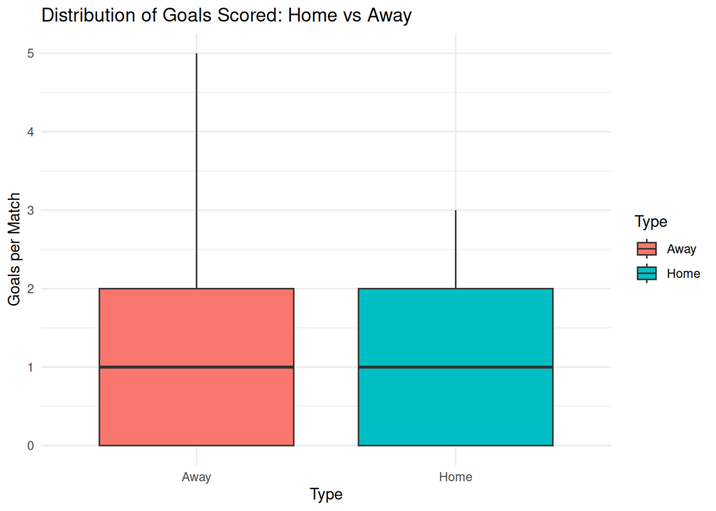

```r
df_long <- df %>% select(FTHG, FTAG) %>%
  pivot_longer(everything(), names_to = "Type", values_to = "Goals") %>%
  mutate(Type = ifelse(Type == "FTHG", "Home", "Away"))

ggplot(df_long, aes(x = Type, y = Goals, fill = Type)) +
  geom_boxplot() +
  labs(title = "Distribution of Goals Scored: Home vs Away", y = "Goals per Match") +
  theme_minimal()
```

A Welch t-test comparing home and away goal means confirms the difference is statistically significant (p < 0.001).

```r
t.test(df$FTHG, df$FTAG, var.equal = FALSE)
```

```
##
##  Welch Two Sample t-test
##
## data:  df$FTHG and df$FTAG
## t = 9.27, df = 20203, p-value < 2.2e-16
## alternative hypothesis: true difference in means is not equal to 0
## 95 percent confidence interval:
##  0.1069908 0.1643680
## sample estimates:
## mean of x mean of y
##   1.27175   1.13607
```

### 7.2.1 Interpretation

Home teams not only win more frequently but also **score more goals** on average. This reinforces theories linking crowd energy and offensive confidence to home performance.

## 7.3 6.3 Points Per Game (PPG)

```r
df_points <- df %>% mutate(
  home_points = case_when(FTR == "H" ~ 3, FTR == "D" ~ 1, TRUE ~ 0),
  away_points = case_when(FTR == "A" ~ 3, FTR == "D" ~ 1, TRUE ~ 0)
)

ppg_summary <- df_points %>% summarize(
  avg_home_ppg = mean(home_points),
  avg_away_ppg = mean(away_points)
)
ppg_summary
```

```
## # A tibble: 1 × 2
##   avg_home_ppg avg_away_ppg
##          <dbl>        <dbl>
## 1         1.53         1.19
```

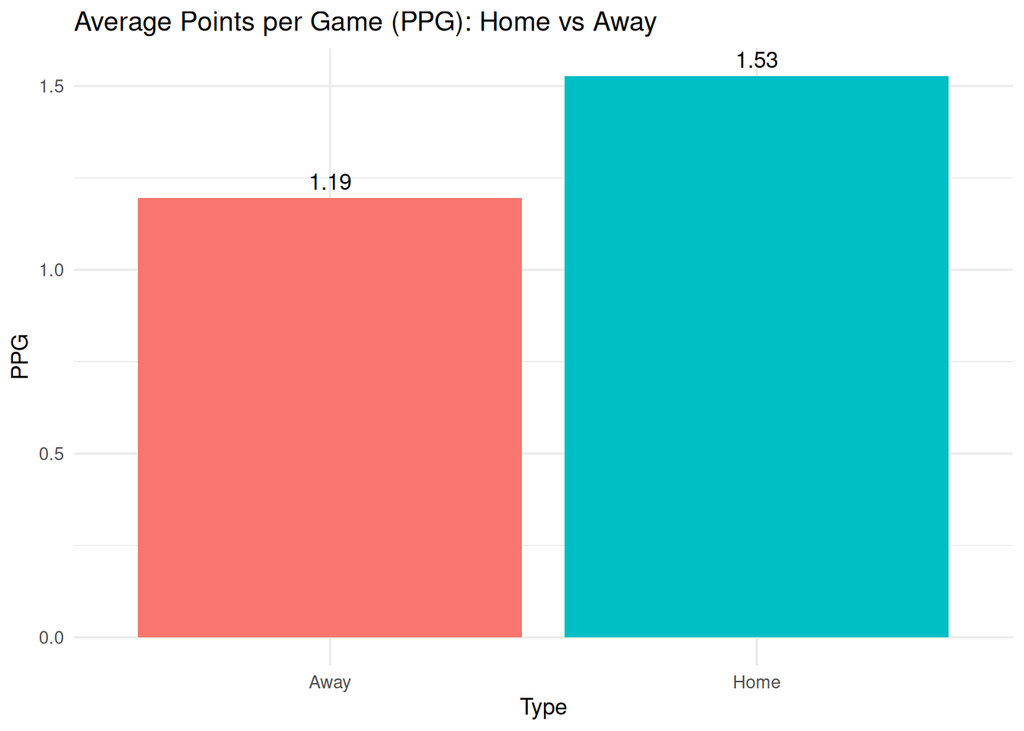

```r
ppg_plot <- ppg_summary %>% pivot_longer(everything(), names_to = "Type", values_to = "PPG") %>%
  mutate(Type = ifelse(Type == "avg_home_ppg", "Home", "Away"))
ggplot(ppg_plot, aes(x = Type, y = PPG, fill = Type)) +
  geom_col(show.legend = FALSE) +
  geom_text(aes(label = round(PPG,2)), vjust=-0.5) +
  labs(title = "Average Points per Game (PPG): Home vs Away", y = "PPG") +
  theme_minimal()
```

## 7.4 6.4 Trends Over Time

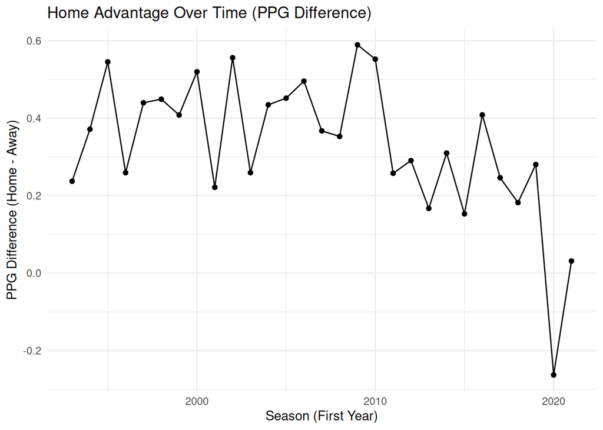

```r
season_summary <- df_points %>% group_by(Season) %>% summarize(
  pct_home_wins = mean(FTR == "H")*100,
  avg_home_ppg = mean(home_points),
  avg_away_ppg = mean(away_points),
  diff_ppg = avg_home_ppg - avg_away_ppg
)
ggplot(season_summary, aes(x = as.integer(substr(Season,1,4)), y = diff_ppg)) +
  geom_line() + geom_point() +
  labs(title = "Home Advantage Over Time (PPG Difference)", y = "PPG Difference (Home - Away)", x = "Season (First Year)") +
  theme_minimal()
```

# 8 7. Discussion

1. **Crowd Influence:** Home supporters create an emotional atmosphere that energizes players and potentially sways referee decisions.
2. **Familiarity with Venue:** Home teams are accustomed to field dimensions, lighting, and turf quality, granting tactical precision.
3. **Travel Fatigue:** Away teams face disruption from travel logistics and overnight stays, reducing physical readiness.
4. **Psychological Confidence:** Players often exhibit stronger self-efficacy and risk-taking behavior when supported by home fans.

The slight decline in home advantage aligns with growing tactical professionalism—teams now plan extensively for away matches, minimizing fatigue effects through optimized travel and recovery schedules. Additionally, the globalization of the Premier League has introduced more diverse playing styles, diluting the traditional comfort factor of local conditions.

# 9 8. Limitations and Future Research

While the study yields robust findings, several limitations must be acknowledged:

- **Lack of Control Variables:** We did not adjust for team quality, injuries, or managerial factors. Stronger teams may inflate home advantage simply by being better overall.
- **Simplified Outcome Coding:** The dataset treats all matches equally, ignoring contextual nuances like derbies or high-stakes fixtures.
- **Omitted Variables:** No measures of attendance, referee identity, or stadium capacity were available, though these factors strongly influence crowd-related effects.
- **Causality:** Our analysis is correlational; while significant differences exist, they cannot confirm direct causation without modeling.

Future work could expand the dataset to include richer contextual variables. Techniques such as **mixed-effects regression** could account for team and season effects, while machine-learning models could predict home advantage probabilities dynamically. Comparative analysis across leagues (e.g., La Liga, Serie A) would also offer valuable cross-cultural insights.

# 10 9. Conclusion

In practical terms, coaches may leverage this insight by emphasizing aggressive home tactics and defensive resilience away. For analysts, the findings highlight the importance of contextual weighting when modeling match outcomes. Ultimately, while the stadium still matters, the advantage it provides is neither uniform nor immutable—it evolves with the modern game.

# 11 10. References

- Bryson, A., Dolton, P., Reade, J. J., Schreyer, D., & Singleton, C. (2021). *Causal effects of an absent crowd on performances and refereeing decisions during COVID-19.* *Economics Letters*, 198, 109664.
- Courneya, K. S., & Carron, A. V. (1992). *The home advantage in sport competitions: A literature review.* *Journal of Sport & Exercise Psychology*, 14(1), 13–27.
- Nevill, A. M., & Holder, R. L. (1999). *Home advantage in sport: An overview of studies on the advantage of playing at home.* *Sports Medicine*, 28(4), 221–236.
- Pollard, R. (2008). *Home advantage in football: A current review of an unsolved puzzle.* *The Open Sports Sciences Journal*, 1, 12–14.
- Goumas, C. (2014). *Home advantage in Australian soccer.* *PLoS ONE*, 9(9), e105041.